# HW 3

Samantha Grayson

2023-11-07

# Load libraries

```r
library(WeightIt)
library(cobalt)
library(stargazer)
library(kableExtra)
library(tidyverse)
```

# 1: Import data

```r
sports <- read.csv("~/Documents/GitHub/Research-Methods-II/HW 3/sports-and-education.csv")
```

# 2: Balance table

```r
covs <- subset(sports, select = c(Academic.Quality, Athletic.Quality, Near.Big.Market))

sports$p.score <- glm(Ranked.2017 ~ Academic.Quality + Athletic.Quality + Near.Big.Market,
                       data = sports,
                       family = "binomial")$fitted.values

sports$att.weights <- with(sports, Ranked.2017 + (1-Ranked.2017)*p.score/(1-p.score))

bal.tab(covs,
        treat = sports$Ranked.2017,
        weights = sports$att.weights,
        disp = c("means", "sds"), un = FALSE,
        stats = c("mean.diffs", "variance.ratios"),
        thresholds = c(m = .1))
```

```
## Balance Measures
##                     Type M.0.Adj SD.0.Adj M.1.Adj SD.1.Adj Diff.Adj
## Academic.Quality Contin.  0.5200   0.3089  0.4665   0.2783  -0.1924
## Athletic.Quality Contin.  0.5576   0.2642  0.5510   0.2813  -0.0234
## Near.Big.Market   Binary  0.6903        .  0.7000        .   0.0097
##                         M.Threshold V.Ratio.Adj
## Academic.Quality Not Balanced, >0.1      0.8116
## Athletic.Quality     Balanced, <0.1      1.1342
## Near.Big.Market      Balanced, <0.1           .
##
## Balance tally for mean differences
##                    count
## Balanced, <0.1         2
## Not Balanced, >0.1     1
##
## Variable with the greatest mean difference
##          Variable Diff.Adj        M.Threshold
##  Academic.Quality  -0.1924 Not Balanced, >0.1
##
## Effective sample sizes
##            Control Treated
## Unadjusted   50.        50
## Adjusted     26.58      50
```

The balance table output indicates that academic quality is unbalanced between ranked and unranked schools. Academic quality is the only covariate where the standard mean difference is above the 0.1 threshold for balance (source: https://cran.r-project.org/web/packages/MatchIt/vignettes/assessing-balance.html). The mean differences are standardized using the col_w_smd() function, which computes the weighted mean differences for binary treatment. Given this information, the balance table failed.

## Make publication-worthy table for the balance table output

```r
balance.table <- bal.tab(covs,
        treat = sports$Ranked.2017,
        weights = sports$att.weights,
        disp = c("means", "sds"), un = FALSE,
        stats = c("mean.diffs", "variance.ratios"),
        thresholds = c(m = .1))

table <- balance.table$Balance

table_output <- table %>%
  select(-c(Type, M.0.Un, SD.0.Un, M.1.Un, SD.1.Un, Diff.Un, V.Ratio.Adj, V.Ratio.Un)) %>%
  dplyr::rename("Unranked School Adj. Mean" = "M.0.Adj") %>%
  dplyr::rename("Unranked School Adj. SD" = "SD.0.Adj") %>%
  dplyr::rename("Ranked School Adj. Mean" = "M.1.Adj") %>%
  dplyr::rename("Ranked School Adj. SD" = "SD.1.Adj") %>%
  dplyr::rename("Mean Difference Adj." = "Diff.Adj") %>%
  dplyr::rename("Mean Threshold (.1)" = "M.Threshold")

rownames(table_output) = c("Academic Quality", "Athletic Quality", "Near a Big Market")


kable(table_output,
      format = "html",
      align = 'c',
      booktabs = TRUE,
      digits = c(2, 2, 2, 2, 2, 2),
      caption = "Balance Table Comparing Ranked and Unranked Schools") %>%
kable_classic() %>%
cat(., file = "~/Documents/GitHub/Research-Methods-II/HW 3/balance_table_output.html")
```

Cool! We have a table output!

# 3: Comment on “propensity score methods are more credible when we (the researchers) are able to use all variables that the agents who assign treatments can use in their assignments.”

There may be unobservables that go into whether a school is ranked (treated) or not that we do not have access to in our dataset. For example, variables like school size, how much budget is allocated to sports, etc. could play a role in whether a given school is ranked. On paper, we may have very good matches, but perhaps we have an Ozzy Osbourne & Prince Charles phenomenon: there are great matches, based on the observables the researchers have access to, but in actuality the matches may be very different.

# 4: Build a propensity score model to predict which colleges were ranked

```r
# First, develop a simple model of who is ranked. Feel free to use linear or logistic regression. Output the coefficients of this model, so that you can show which factors predict (and which don't).

logistic_model <- glm(Ranked.2017 ~ Academic.Quality + Athletic.Quality + as.factor(Near.Big.Market),
                       data = sports,
                       family = "binomial")

summary(logistic_model)
```

```
##
## Call:
## glm(formula = Ranked.2017 ~ Academic.Quality + Athletic.Quality +
##     as.factor(Near.Big.Market), family = "binomial", data = sports)
##
## Coefficients:
##                             Estimate Std. Error z value Pr(>|z|)
## (Intercept)                  -1.3779     0.6450  -2.136 0.032656 *
## Academic.Quality             -0.8837     0.7803  -1.133 0.257403
## Athletic.Quality              1.9638     0.8060   2.437 0.014827 *
## as.factor(Near.Big.Market)1   1.6155     0.4589   3.520 0.000432 ***
## ---
## Signif. codes:  0 '***' 0.001 '**' 0.01 '*' 0.05 '.' 0.1 ' ' 1
##
## (Dispersion parameter for binomial family taken to be 1)
##
##     Null deviance: 138.63  on 99  degrees of freedom
## Residual deviance: 119.11  on 96  degrees of freedom
## AIC: 127.11
##
## Number of Fisher Scoring iterations: 4
```

The logistic regression table output indicates that athletic quality and near big markets are significant predictors of whether a school is ranked or not.

```r
# For each observation, predict the probability of treatment.

sports$p.score <- glm(Ranked.2017 ~ Academic.Quality + Athletic.Quality + Near.Big.Market,
                       data = sports,
                       family = "binomial")$fitted.values
```

We take the fitted values and create a new column with the p.scores for each observation.

## Make publication-worthy table

```r
model_results1 <- stargazer(logistic_model,
                            title="Simple Model of Who is Ranked in 2017 ",
                            type = "html",
                            dep.var.labels=c("Ranked in 2017"),
                            covariate.labels=c("Academic Quality",
                                               "Athletic Quality",
                                               "Near a Big Market (1)"))
```

[output not shown]

```r
capture.output(model_results1, file = "~/Documents/GitHub/Research-Methods-II/HW 3/logistic_model.html")
```

# 5: Use stacked histograms to show overlap in the between ranked and unranked schools.

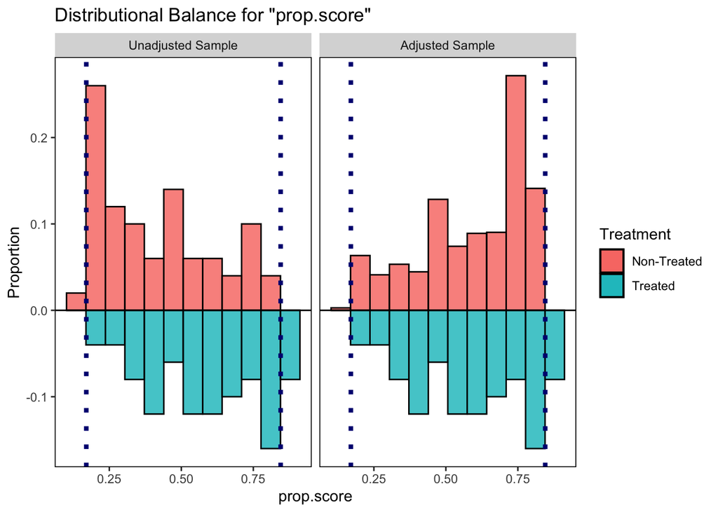

```r
W.out <- WeightIt::weightit(Ranked.2017 ~ Academic.Quality + Athletic.Quality + Near.Big.Market,
                            data = sports,
                            method = "glm",
                            estimand = "ATT")

# Plot 1
Plot <- bal.plot(W.out, var.name = "prop.score",
         which = "both",
         type = "histogram",
         mirror = TRUE)

Plot +
  scale_fill_discrete(name = "Treatment", labels = c("Non-Treated", "Treated"))+
  geom_vline(xintercept = 0.17, linetype="dotted",
                color = "navy", size=1.5)+
  geom_vline(xintercept = 0.845, linetype="dotted",
                color = "navy", size=1.5)
```

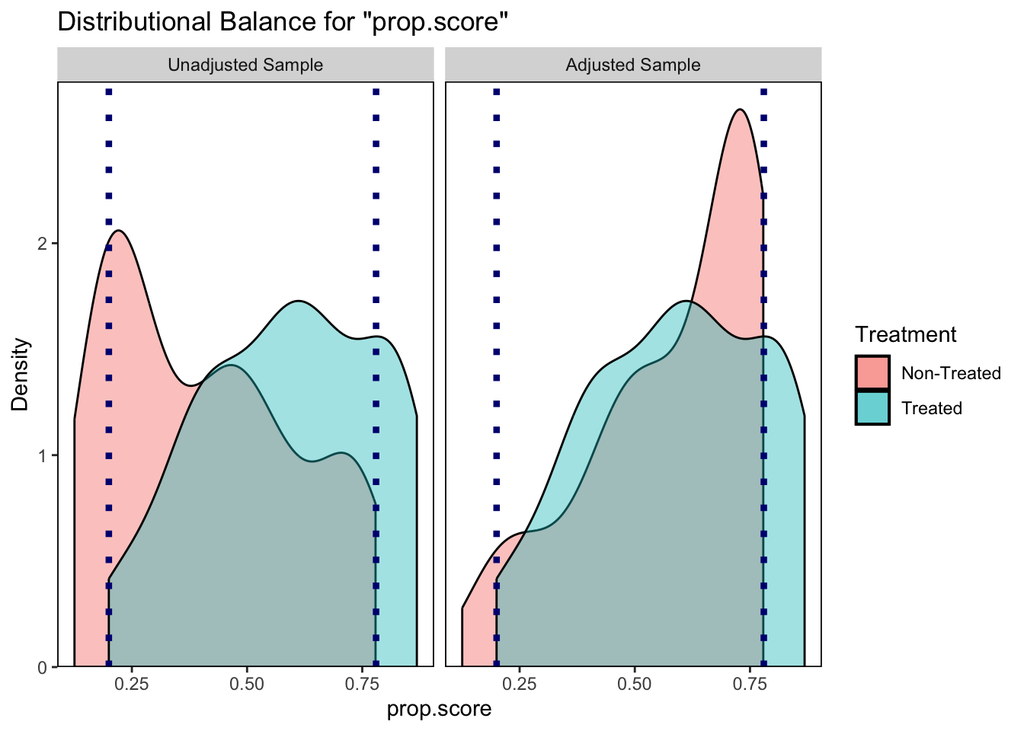

```r
# Plot 2
Plot2 <- bal.plot(W.out, "prop.score", which = "both")

Plot2 +
  scale_fill_discrete(name = "Treatment", labels = c("Non-Treated", "Treated"))+
  geom_vline(xintercept = 0.2, linetype="dotted",
                color = "navy", size=1.5)+
  geom_vline(xintercept = 0.78, linetype="dotted",
                color = "navy", size=1.5)
```

Both plots show (in slightly different ways) that the area of overlap between non-treated (unranked) and treated (ranked) schools is approximately between p.score = 0.2 and p.score = 0.8. Values on the far right (p.score > 0.8) and far left (p.score <0.2) do not overlap. We did not address how to drop these observations in class.

# 6: Group your observations into ‘blocks’ based on propensity score.

```r
sports_sorted <- sports %>%
  arrange(p.score) %>%
  mutate(row.id = row_number()) %>%
  mutate(block = ceiling(row.id/4)) %>%
  select(-row.id)
```

The p.scores are blocked in groups of 4 in ascending order. Need to make them into factors for the model, but will suppress them in the publication-quality table, because that’s annoying to look at.

# 7: Analyze the treatment effect of being ranked on alumni donations, while controlling for block-fixed effects as well as other covariates.

```r
model <- lm(Alumni.Donations.2018 ~ as.factor(Ranked.2017) + p.score + Academic.Quality + Athletic.Quality + as.factor(Near.Big.Market) + as.factor(block), data = sports_sorted)

summary(model)
```

```
##
## Call:
## lm(formula = Alumni.Donations.2018 ~ as.factor(Ranked.2017) +
##     p.score + Academic.Quality + Athletic.Quality + as.factor(Near.Big.Market) +
##     as.factor(block), data = sports_sorted)
##
## Residuals:
##     Min      1Q  Median      3Q     Max
## -2.0767 -0.6188  0.0809  0.5243  2.1733
##
## Coefficients:
##                             Estimate Std. Error  t value Pr(>|t|)
## (Intercept)                 -27.3871     8.7064   -3.146  0.00243 **
## as.factor(Ranked.2017)1     500.5897     0.2613 1916.001  < 2e-16 ***
## p.score                     130.3684    41.1083    3.171  0.00225 **
## Academic.Quality            119.2728     6.5816   18.122  < 2e-16 ***
## Athletic.Quality              7.4284    14.6429    0.507  0.61354
## as.factor(Near.Big.Market)1 964.6185    12.0640   79.959  < 2e-16 ***
## as.factor(block)2             1.3001     0.8000    1.625  0.10863
## as.factor(block)3             0.6773     0.9840    0.688  0.49354
## as.factor(block)4             1.6317     1.1517    1.417  0.16097
## as.factor(block)5             1.0902     1.2746    0.855  0.39530
## as.factor(block)6             0.5287     1.4901    0.355  0.72383
## as.factor(block)7            -1.5582     1.9182   -0.812  0.41935
## as.factor(block)8            -2.4582     2.1161   -1.162  0.24932
## as.factor(block)9            -4.6281     2.5472   -1.817  0.07350 .
## as.factor(block)10           -5.0568     2.7342   -1.849  0.06861 .
## as.factor(block)11           -5.6093     2.9812   -1.882  0.06406 .
## as.factor(block)12           -6.3526     3.3378   -1.903  0.06112 .
## as.factor(block)13           -7.3615     3.5496   -2.074  0.04177 *
## as.factor(block)14           -9.4394     4.0900   -2.308  0.02396 *
## as.factor(block)15          -10.5393     4.3890   -2.401  0.01900 *
## as.factor(block)16          -12.2596     4.6800   -2.620  0.01079 *
## as.factor(block)17          -12.8100     5.0355   -2.544  0.01317 *
## as.factor(block)18          -13.9056     5.4344   -2.559  0.01267 *
## as.factor(block)19          -14.4736     5.8521   -2.473  0.01582 *
## as.factor(block)20          -15.3258     6.2059   -2.470  0.01597 *
## as.factor(block)21          -16.0577     6.4149   -2.503  0.01464 *
## as.factor(block)22          -17.1425     6.7762   -2.530  0.01367 *
## as.factor(block)23          -16.8532     6.9714   -2.417  0.01824 *
## as.factor(block)24          -16.7748     7.1557   -2.344  0.02191 *
## as.factor(block)25          -15.5741     7.3163   -2.129  0.03680 *
## ---
## Signif. codes:  0 '***' 0.001 '**' 0.01 '*' 0.05 '.' 0.1 ' ' 1
##
## Residual standard error: 0.986 on 70 degrees of freedom
## Multiple R-squared:      1,  Adjusted R-squared:      1
## F-statistic: 1.417e+06 on 29 and 70 DF,  p-value: < 2.2e-16
```

The regression table output indicates that whether a school is ranked in 2017, p.score, academic quality, and whether a school is near big markets are significant predictors of alumni donations in 2018. Additionally, some block factors (for those with higher propensity scores) are significantly different from the reference category of block (1). In other words, controlling for block, p.score, academic quality, athletic quality, and near a big market, schools that were ranked (treated) in 2017 received over $500,000 more on average in alumni donations in 2018 than unranked schools (untreated).

## Make publication-worthy table

```r
model_results1 <- stargazer(model,
                            title="Alumni Donations, Blocks, and Covariates Table",
                            type = "html",
                            dep.var.labels=c("Alumni Donations"),
                            covariate.labels=c("Ranked in 2017 (1)",
                                               "P-score",
                                               "Academic Quality",
                                               "Athletic Quality",
                                               "Near a Big Market (1)",
                                               "Block 2",
                                               "Block 3",
                                               "Block 4",
                                               "Block 5",
                                               "Block 6",
                                               "Block 7",
                                               "Block 8",
                                               "Block 9",
                                               "Block 10",
                                               "Block 11",
                                               "Block 12",
                                               "Block 13",
                                               "Block 14",
                                               "Block 15",
                                               "Block 16",
                                               "Block 17",
                                               "Block 18",
                                               "Block 19",
                                               "Block 20",
                                               "Block 21",
                                               "Block 22",
                                               "Block 23",
                                               "Block 24",
                                               "Block 25"))
```

[output not shown]

[output cut: 47 more lines]

[output not shown]

```r
capture.output(model_results1, file = "~/Documents/GitHub/Research-Methods-II/HW 3/model.html")
```